# Importing and Visualizing Data

Andrew Stier

1/20/2020

```r
library(tidyverse)
theme_set(theme_minimal())
```

Here is where we read in the raw data.

```r
# In the raw data, there is one file per subject. This is making a list of all the files we need to read in
root_dir <- "/home/expdes/demos/OnlineExperiment/"
file_list <- list.files(path = root_dir, pattern = "\\.txt$")
# This is saving the number of subjects we have, to use later
n <- length(file_list)
# This is creating an empty dataframe to put all of the data into
dataset <- data.frame()

# This is a for loop, to read in and process each file in the folder
for (i in 1:length(file_list)){
  # This is a temporary file for the ith file in the list
  tempdat <- read.table(file = file.path(root_dir,file_list[i]))
  # I'm only saving the columns I need since some don't apply to this analysis
  tempdat <- tempdat[,c(1,4:7)]
  # I know that this is the order of columns that I kept. I'm adding names to the columns for clarity
  colnames(tempdat) <- c("Image","MemLevel","MemCue","RT","Performance")
  # This adds a column that notes which subject the data is for
  tempdat$Subject <- as.factor(i)
  # This joins the current file to the earlier processed files
  dataset <- rbind(dataset, tempdat)
}
# This deletes the last tempdat file after processing
remove(tempdat)

# Most of our columns should be treated as factors, not integers
dataset$Image <- as.factor(dataset$Image)
dataset$MemLevel <- as.factor(dataset$MemLevel)
dataset$MemCue <- as.factor(dataset$MemCue)
dataset$Performance <- as.factor(dataset$Performance)
```

Let’s look at the first few rows of the data

```r
head(dataset)
```

```
##   Image MemLevel MemCue   RT Performance Subject
## 1   116        3      4 1500           3       1
## 2    94        3      4  866           2       1
## 3   123        3      4  886           2       1
## 4     7        1      1 1334           2       1
## 5    48        2      3 1069           1       1
## 6    81        2      1 1093           1       1
```

```r
#Image = identifier of image for trial
#MemLevel = how memorable the image is (1=low,2=medium,3=high,4=foil)
#MemCue = memorability cue (1=remember, 2=forget, 3=foil)
#RT= reaction time in MS
#Performance = performance (1=correct, 2=incorrect, 3=timeout)
#Subject
```

We can look at the last few rows as well.

```r
tail(dataset)
```

```
##      Image MemLevel MemCue   RT Performance Subject
## 5395    71        2      1  801           1      30
## 5396   152        3      4 1197           2      30
## 5397   164        3      4  799           2      30
## 5398   160        3      4  814           1      30
## 5399    55        2      2  654           1      30
## 5400    69        2      3  874           1      30
```

So that I don’t have to create the dataset again when I work on this project in the future, I’m going to export it as a csv with all the subjects together.

```r
write_csv(dataset, "/home/expdes/local/topdownattention.csv")
# To start from that csv:
# dataset <- read_csv("topdownattention.csv")
# dataset$Image <- as.factor(dataset$Image)
# dataset$MemLevel <- as.factor(dataset$MemLevel)
# dataset$MemCue <- as.factor(dataset$MemCue)
# dataset$Performance <- as.factor(dataset$Performance)
```

Let’s get a summary of our dataset to see what the variables look like.

```r
summary(dataset)
```

```
##      Image      MemLevel MemCue         RT         Performance    Subject
##  1      :  30   1:1350   1: 900   Min.   :   2.0   1:2952      1      : 180
##  2      :  30   2:1350   2: 900   1st Qu.: 572.0   2:1923      2      : 180
##  3      :  30   3:2700   3: 900   Median : 747.0   3: 525      3      : 180
##  4      :  30            4:2700   Mean   : 778.2               4      : 180
##  5      :  30                     3rd Qu.: 957.0               5      : 180
##  6      :  30                     Max.   :1533.0               6      : 180
##  (Other):5220                                                  (Other):4320
```

What about getting summary statistics by groups?

```r
dataset %>% group_by(MemLevel) %>% summarise(meanRT=mean(RT), sdRT=sd(RT))
```

```
## # A tibble: 3 × 3
##   MemLevel meanRT  sdRT
##   <fct>     <dbl> <dbl>
## 1 1          781.  371.
## 2 2          768.  353.
## 3 3          782.  366.
```

```r
dataset %>% group_by(MemLevel) %>% count(Performance)
```

```
## # A tibble: 9 × 3
## # Groups:   MemLevel [3]
##   MemLevel Performance     n
##   <fct>    <fct>       <int>
## 1 1        1             592
## 2 1        2             618
## 3 1        3             140
## 4 2        1             789
## 5 2        2             440
## 6 2        3             121
## 7 3        1            1571
## 8 3        2             865
## 9 3        3             264
```

We can group by a different variable easily, or group by more than one variable

```r
dataset %>% group_by(MemCue) %>% count(Performance)
```

```
## # A tibble: 12 × 3
## # Groups:   MemCue [4]
##    MemCue Performance     n
##    <fct>  <fct>       <int>
##  1 1      1             457
##  2 1      2             361
##  3 1      3              82
##  4 2      1             461
##  5 2      2             340
##  6 2      3              99
##  7 3      1             463
##  8 3      2             357
##  9 3      3              80
## 10 4      1            1571
## 11 4      2             865
## 12 4      3             264
```

```r
#Note, R will give the same results with: dataset %>% count(MemCue, Performance) but I find that less intuitive.

dataset %>% group_by(MemLevel, MemCue) %>% summarise(meanRT=mean(RT), seRT=sd(RT)/sqrt(n()))
```

```
## # A tibble: 7 × 4
## # Groups:   MemLevel [3]
##   MemLevel MemCue meanRT  seRT
##   <fct>    <fct>   <dbl> <dbl>
## 1 1        1        776. 17.2
## 2 1        2        799. 18.3
## 3 1        3        768. 17.0
## 4 2        1        771. 16.5
## 5 2        2        767. 17.1
## 6 2        3        766. 16.3
## 7 3        4        782.  7.04
```

Now let’s plot our data using ggplot2.

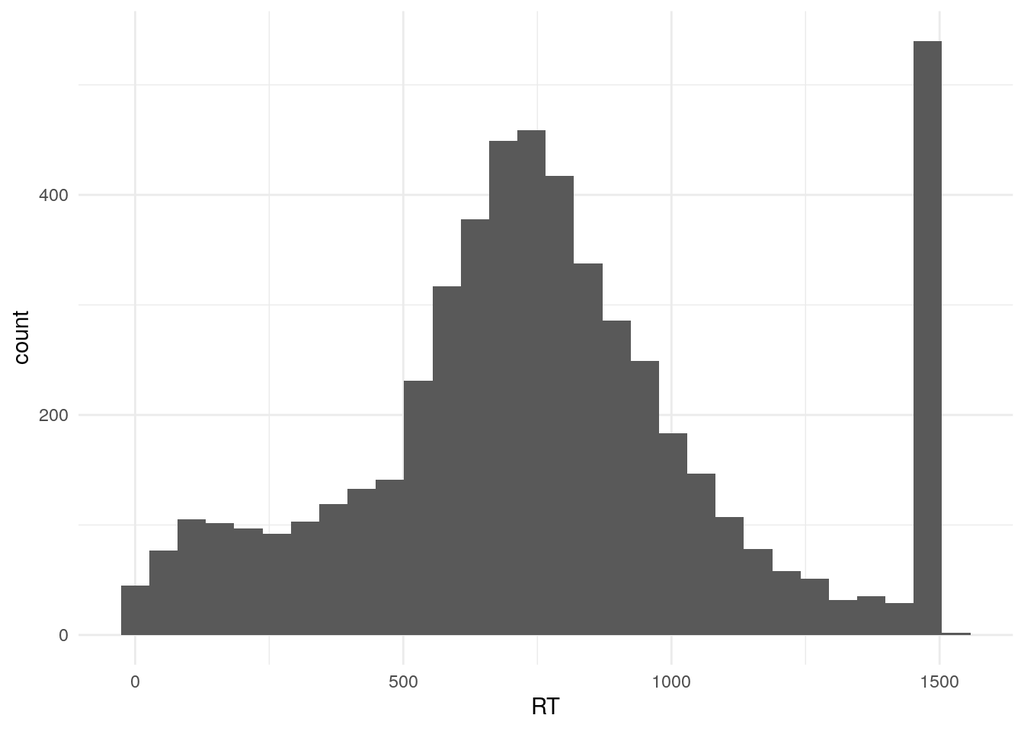

```r
ggplot(data=dataset) + aes(x=RT) + geom_histogram()
```

The trials only lasted for 1500ms so it looks like there are some trials where RT was collected after the trial was over. Let’s filter out those trials.

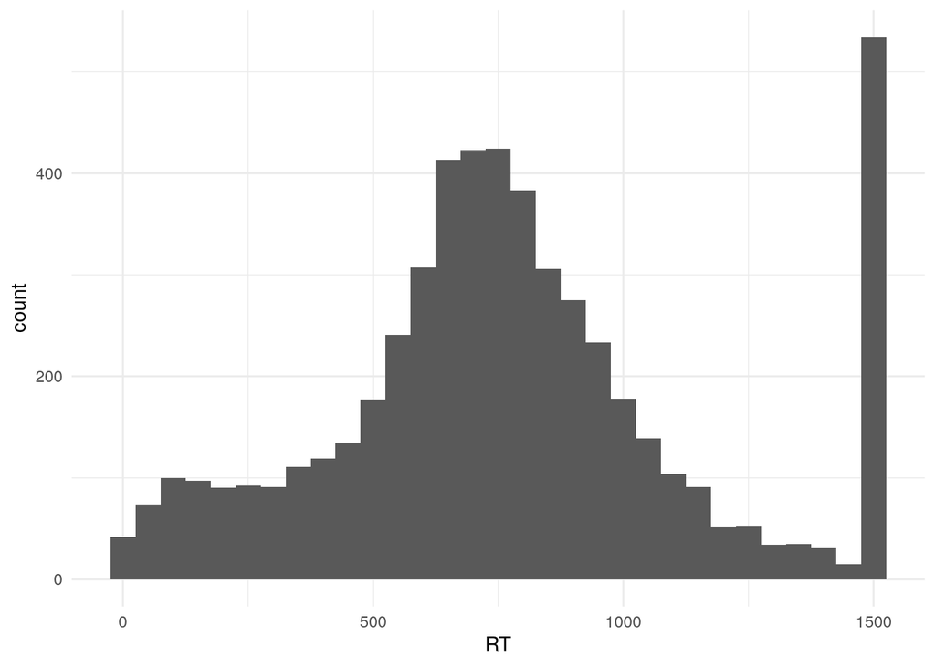

```r
dataset_notovertime <- dataset %>% filter(RT <= 1500)
ggplot(data=dataset_notovertime)+ aes(x=RT) + geom_histogram(binwidth = 50)
```

Why do you think there is a spike at 1500 ms?

```r
dataset_notovertime %>% filter(RT=="1500") %>% summary()
```

```
##      Image     MemLevel MemCue        RT       Performance    Subject
##  33     :  6   1:140    1: 82   Min.   :1500   1:  0       3      :161
##  3      :  5   2:121    2: 99   1st Qu.:1500   2:  1       4      : 89
##  5      :  5   3:265    3: 80   Median :1500   3:525       18     : 87
##  28     :  5            4:265   Mean   :1500               2      : 75
##  34     :  5                    3rd Qu.:1500               14     : 35
##  44     :  5                    Max.   :1500               11     : 15
##  (Other):495                                               (Other): 64
```

So lets create a new database where we only keep trials with a RT faster than the timeout time

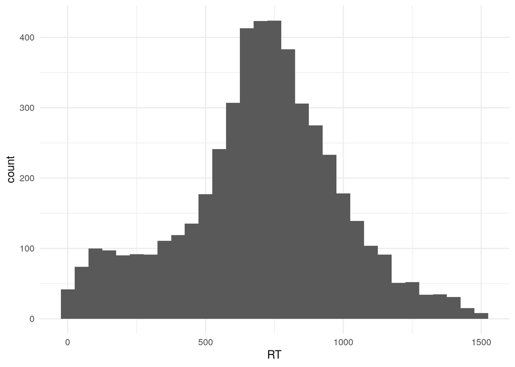

```r
notimeout <- dataset_notovertime %>% filter(RT < 1500)
ggplot(data=notimeout)+ aes(x=RT) + geom_histogram(binwidth = 50)
```

What about making a histogram of memory performance?

We first need to calculate a hit rate for each person (hit/(hit + miss)).

```r
bysubject <- dataset %>% group_by(Subject) %>% count(Performance)
head(bysubject)
```

```
## # A tibble: 6 × 3
## # Groups:   Subject [2]
##   Subject Performance     n
##   <fct>   <fct>       <int>
## 1 1       1             102
## 2 1       2              77
## 3 1       3               1
## 4 2       1              53
## 5 2       2              52
## 6 2       3              75
```

```r
#pivot_wider is going to take a name-value pair and spread it over multiple columns, and then we rename the columns so we don't have to remember the mapping
wide_bysubject <- bysubject %>% pivot_wider(names_from = Performance, values_from = n, values_fill = list(n = 0)) %>% rename(Correct=`1`, Incorrect=`2`, Timeout=`3`)
head(wide_bysubject)
```

```
## # A tibble: 6 × 4
## # Groups:   Subject [6]
##   Subject Correct Incorrect Timeout
##   <fct>     <int>     <int>   <int>
## 1 1           102        77       1
## 2 2            53        52      75
## 3 3            10         9     161
## 4 4            45        46      89
## 5 5           131        45       4
## 6 6           139        40       1
```

```r
#Now we can calculate our hit rate (Correct/Correct + Incorrect). We will ignore Timeout for now.
wide_bysubject <- wide_bysubject %>% mutate(HitRate = Correct/(Correct + Incorrect))
head(wide_bysubject)
```

```
## # A tibble: 6 × 5
## # Groups:   Subject [6]
##   Subject Correct Incorrect Timeout HitRate
##   <fct>     <int>     <int>   <int>   <dbl>
## 1 1           102        77       1   0.570
## 2 2            53        52      75   0.505
## 3 3            10         9     161   0.526
## 4 4            45        46      89   0.495
## 5 5           131        45       4   0.744
## 6 6           139        40       1   0.777
```

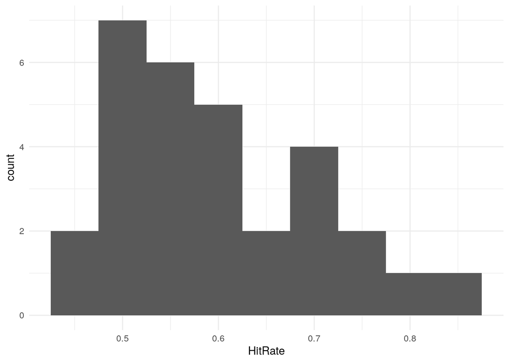

```r
ggplot(data=wide_bysubject) + aes(x = HitRate) + geom_histogram(binwidth = .05)
```

Low Memorability x Remember

Low Memorability x Forget

Medium Memorability x Remember

Medium Memorability x Forget

High Memorability x Remember

High Memorability x Forget

```r
bysubject_level_cue <- dataset %>% group_by(Subject, MemLevel, MemCue) %>% count(Performance)
head(bysubject_level_cue)
```

```
## # A tibble: 6 × 5
## # Groups:   Subject, MemLevel, MemCue [3]
##   Subject MemLevel MemCue Performance     n
##   <fct>   <fct>    <fct>  <fct>       <int>
## 1 1       1        1      1              14
## 2 1       1        1      2               1
## 3 1       1        2      1              12
## 4 1       1        2      2               3
## 5 1       1        3      1              13
## 6 1       1        3      2               2
```

```r
#Dropping foil images
bysubject_level_cue <- bysubject_level_cue %>% filter(MemLevel != "4") %>% droplevels()

#pivot_wider is going to take a name-value pair and spread it over multiple columns
wide_bysubject_level_cue <- bysubject_level_cue %>%
  pivot_wider(names_from = Performance, values_from = n, values_fill = list(n = 0)) %>%
  rename(Correct=`1`, Incorrect=`2`, Timeout=`3`)
head(wide_bysubject_level_cue)
```

```
## # A tibble: 6 × 6
## # Groups:   Subject, MemLevel, MemCue [6]
##   Subject MemLevel MemCue Correct Incorrect Timeout
##   <fct>   <fct>    <fct>    <int>     <int>   <int>
## 1 1       1        1           14         1       0
## 2 1       1        2           12         3       0
## 3 1       1        3           13         2       0
## 4 1       2        1           12         3       0
## 5 1       2        2           12         3       0
## 6 1       2        3           15         0       0
```

```r
#Since I said we didn't care about the timeout trials, we can drop that column to clean up the dataframe
wide_bysubject_level_cue <- wide_bysubject_level_cue %>% dplyr::select(-Timeout)

wide_bysubject_level_cue <- wide_bysubject_level_cue %>% mutate(HitRate = Correct/(Correct + Incorrect))
head(wide_bysubject_level_cue)
```

```
## # A tibble: 6 × 6
## # Groups:   Subject, MemLevel, MemCue [6]
##   Subject MemLevel MemCue Correct Incorrect HitRate
##   <fct>   <fct>    <fct>    <int>     <int>   <dbl>
## 1 1       1        1           14         1   0.933
## 2 1       1        2           12         3   0.8
## 3 1       1        3           13         2   0.867
## 4 1       2        1           12         3   0.8
## 5 1       2        2           12         3   0.8
## 6 1       2        3           15         0   1
```

Now let’s create a histogram that shows the different groups.

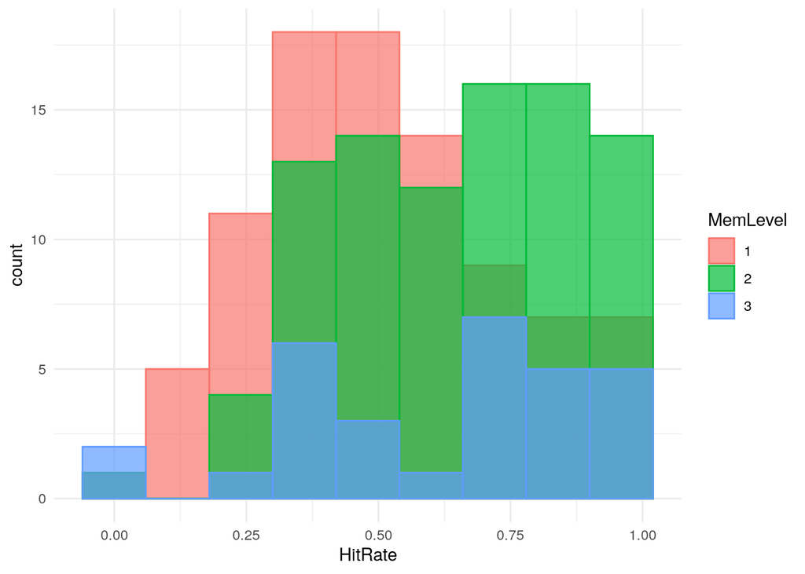

```r
ggplot(data=wide_bysubject_level_cue) +
  #fill sets the color inside the box, while color sets the edge of the box
  aes(x = HitRate, fill=MemLevel, color=MemLevel) +
  #alpha sets the transparency; position overlays the values on top of each other
  geom_histogram(binwidth = .12, alpha=.7, position = "identity")
```

That’s okay, but it’s still a little hard to see where they all overlap. We can adjust the positions. Be sure to play around with the binwidth to see how it changes the plot.

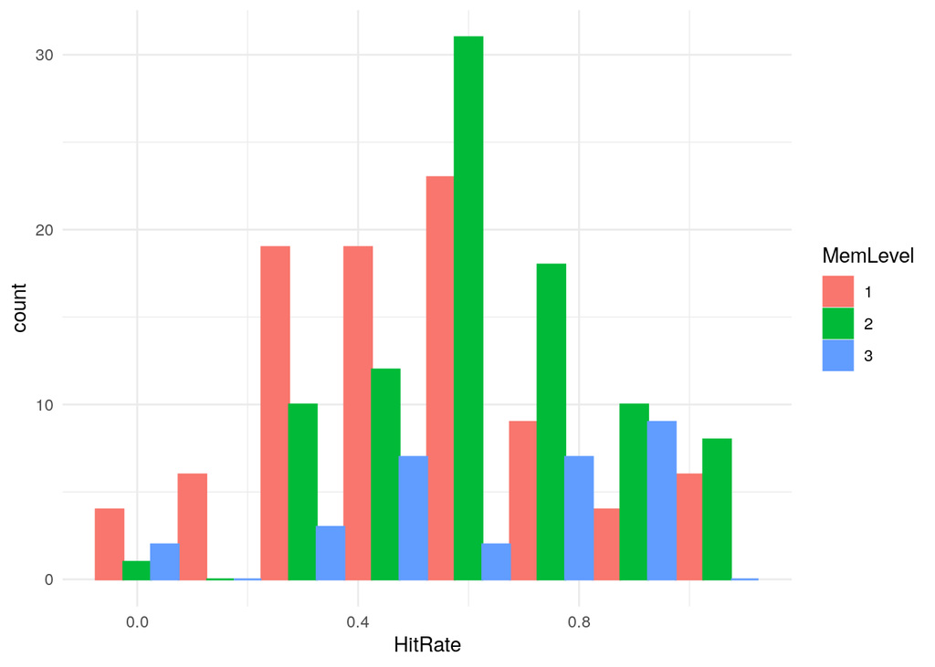

```r
ggplot(data=wide_bysubject_level_cue) +
  aes(x = HitRate, fill=MemLevel, color=MemLevel) +
  #Dodge adjust the positions so they aren't on top of each other. A little more difficult to see the exact values the bars represent on the x-axis, but easier to see how the distributions overlap
  geom_histogram(binwidth = .15, position = "dodge")
```

To create a barplot, we still need to calculate mean hit rate for each of the conditions listed above

```r
HRbyCond <- wide_bysubject_level_cue %>% group_by(MemLevel, MemCue) %>% summarise(meanHR = mean(HitRate), seHR = sd(HitRate)/sqrt(n()))
HRbyCond
```

```
## # A tibble: 7 × 4
## # Groups:   MemLevel [3]
##   MemLevel MemCue meanHR   seHR
##   <fct>    <fct>   <dbl>  <dbl>
## 1 1        1       0.508 0.0463
## 2 1        2       0.534 0.0455
## 3 1        3       0.491 0.0407
## 4 2        1       0.634 0.0393
## 5 2        2       0.660 0.0377
## 6 2        3       0.638 0.0446
## 7 3        4       0.608 0.0495
```